# Analyzing the Dissimilarity Indices for the PSRC region

Data Science

June 2021

# Does Single Family Zoning correlate with greater segregation?

The dissimilarity index was calculated at a block group level. The Future Land Use Layer was used to represent zoning with the field Max Dwelling Units per Acre.

So from a technical standpoint, we are looking into:

### Does the Maximum Dwelling Units per Acre in a Block Group correlate with the Dissimilarity Index of the Block Group?

The segregation measure is a set of dissimilarity indices between racial groups. Between any two groups a measure of dissimilarity is calculated for each block group. More documentation can be found here: https://www.censusscope.org/about_dissimilarity.html

Because the future land use layer and the block groups do not match up geographically, I needed to do an aggregation to get a one to one match between the future land use and the block groups. For this, I found the max, min, and mean maximum du for a block group for all intersecting flu areas.

```
## flu_dissim$max_max_du
##        n  missing distinct     Info     Mean      Gmd      .05      .10
##     2640        0      172    0.999    57.92    67.47     0.20     5.00
##      .25      .50      .75      .90      .95
##    10.89    30.00    78.41   150.00   185.13
##
## lowest :    0.025    0.100    0.200    0.250    0.400
## highest:  479.160  516.186  566.280  600.000 1012.000
```

```
## flu_dissim$min_max_du
##        n  missing distinct     Info     Mean      Gmd      .05      .10
##     2640        0       79    0.856    4.242    6.703     0.00     0.00
##      .25      .50      .75      .90      .95
##     0.00     0.00     6.00     8.70     9.68
##
## lowest :   0.00000000   0.02500000   0.02857143   0.05000000   0.10000000
## highest: 121.96800000 126.32400000 139.39200000 217.80000000 313.63200000
```

```
## flu_dissim$mean_max_du
##        n  missing distinct     Info     Mean      Gmd      .05      .10
##     2640        0     2034        1    24.05    29.03    0.150    1.565
##      .25      .50      .75      .90      .95
##    4.896   12.121   29.624   55.911   73.238
##
## lowest :   0.02500000   0.04000000   0.04375000   0.04878049   0.05000000
## highest: 375.66144000 378.97200000 379.72000000 413.82000000 472.62600000
```

```
## flu_dissim$White_Black_Dissim
##        n  missing distinct     Info     Mean      Gmd      .05      .10
##     2640        0     2447        1 0.002535    6.303  -13.240   -7.363
##      .25      .50      .75      .90      .95
##   -1.178    2.151    3.746    5.133    6.086
##
## lowest : -80.23934 -73.21359 -60.98819 -59.99343 -53.14220
## highest:  10.54558  11.45539  13.59205  13.88471  15.16752
```

```
## flu_dissim$White_Minority_Dissim
##         n   missing  distinct      Info      Mean       Gmd       .05       .10
##      2640         0      2637         1 0.0006692     3.779   -6.6119   -4.7278
##       .25       .50       .75       .90       .95
##   -1.8155    0.7146    2.4032    3.6327    4.4206
##
## lowest : -18.734869 -17.408798 -17.308878 -16.358890 -16.072008
## highest:   7.888457   8.306193   8.374410   8.431756   8.961172
```

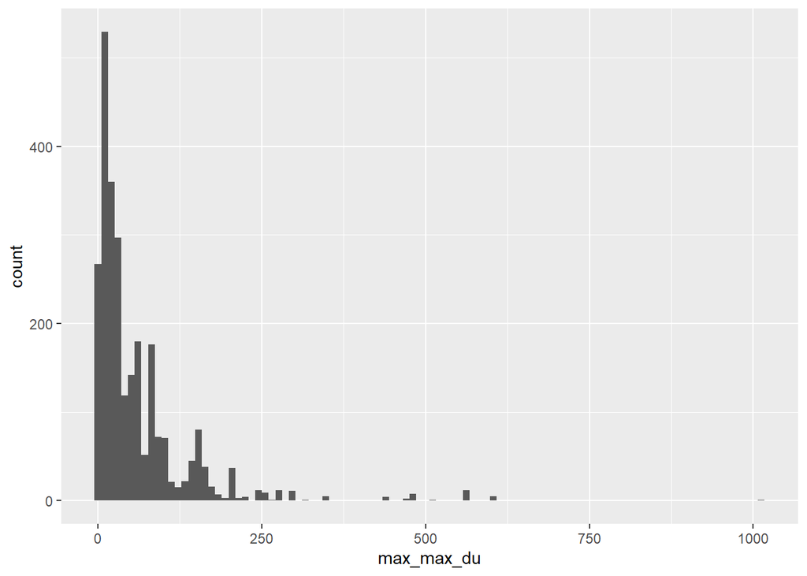

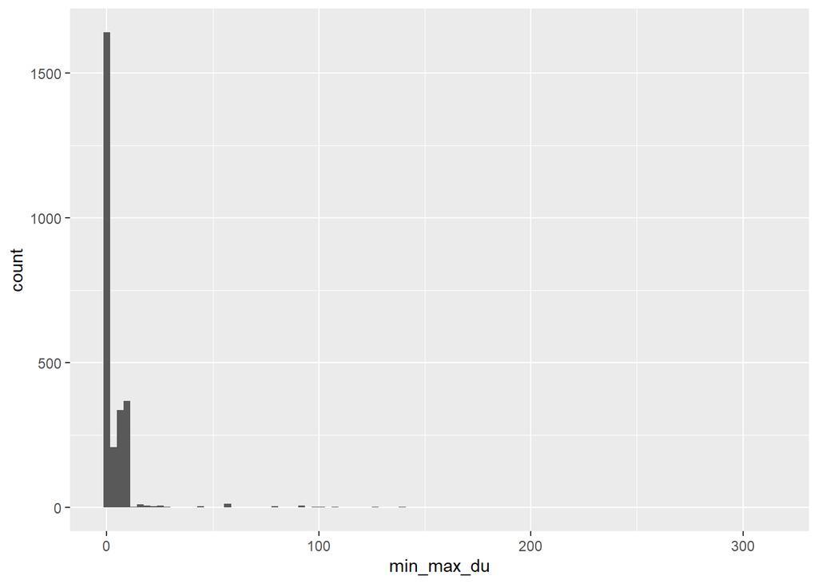

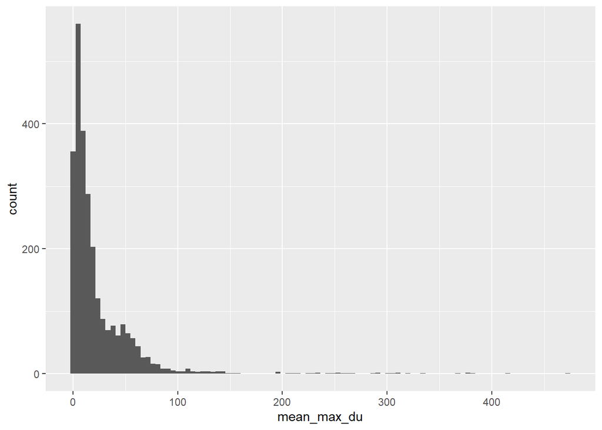

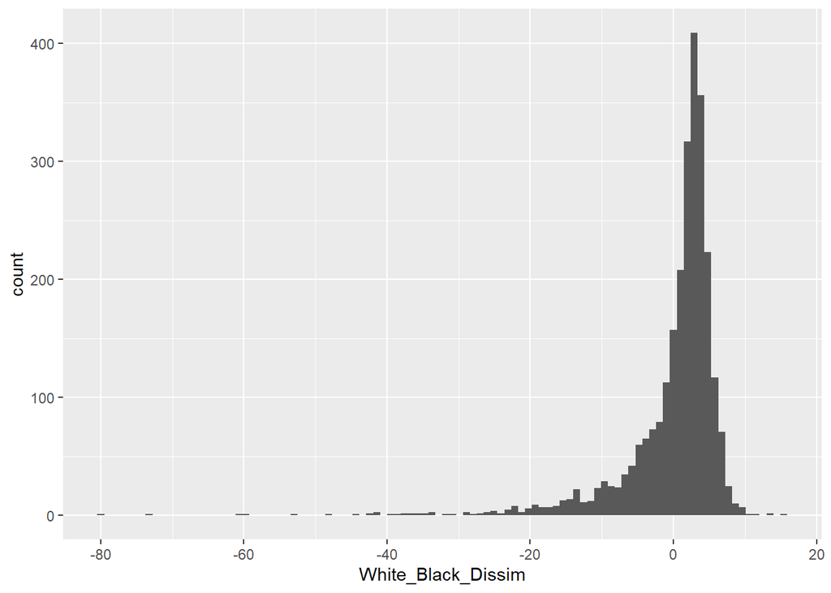

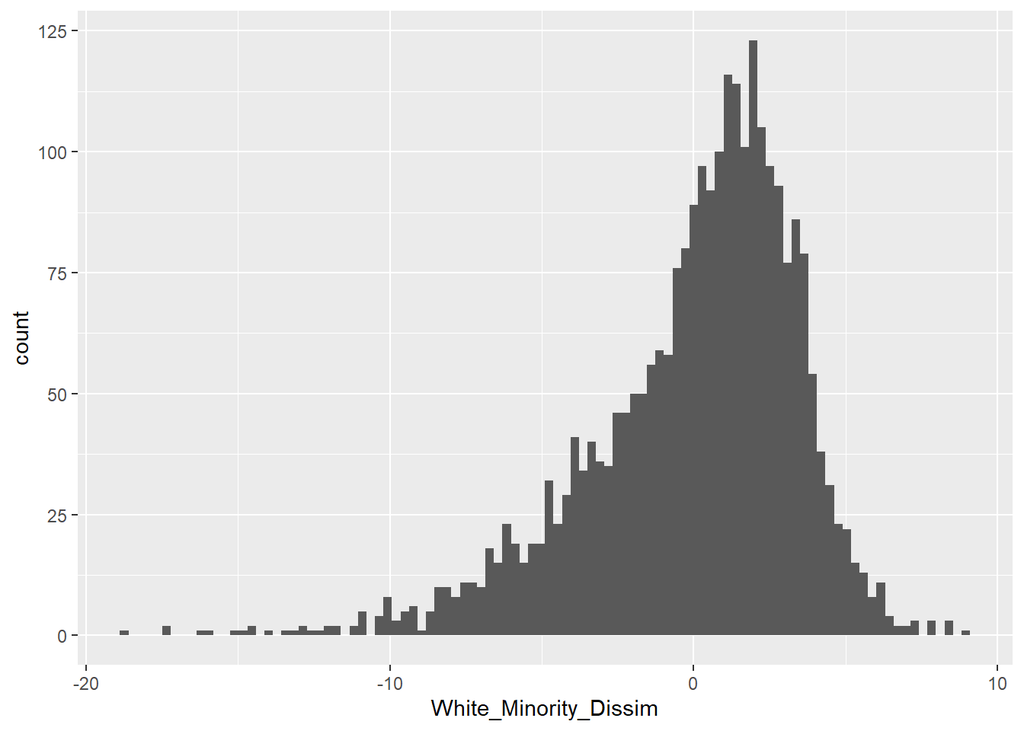

There are long tails on the max dus. I’m going to cap them at 100. I think I’ll use max_max_du at this point too.

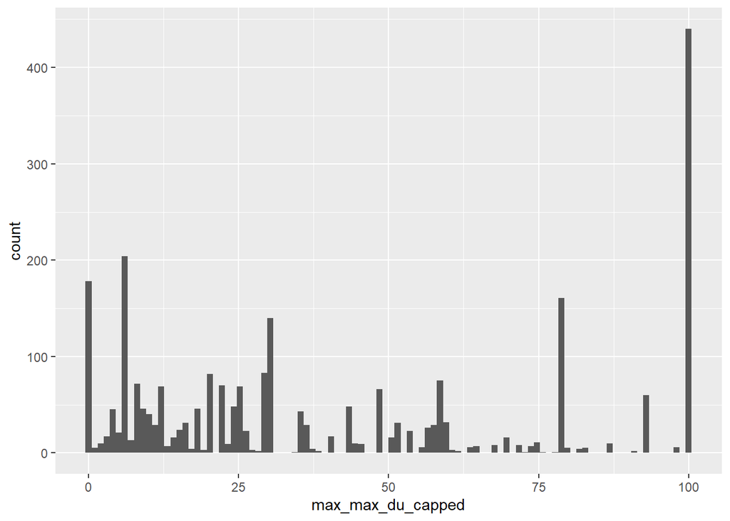

```r
flu_dissim<- flu_dissim %>%mutate(max_max_du_capped=replace(max_max_du,max_max_du>100,100))

ggplot(flu_dissim, aes(x=max_max_du_capped)) + geom_histogram(bins=100)
```

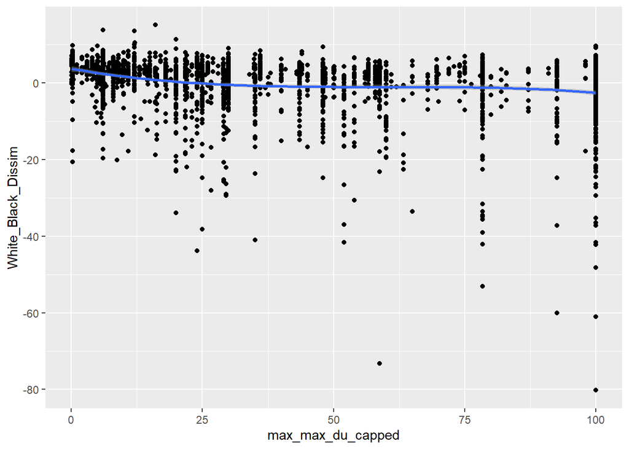

```r
ggplot(flu_dissim, aes(x=max_max_du_capped, y=White_Black_Dissim))+
  geom_point()+
  geom_smooth(method=lm, formula='y ~poly(x,3)')
```

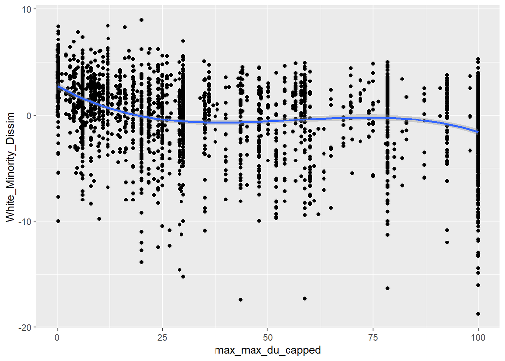

```r
ggplot(flu_dissim, aes(x=max_max_du_capped, y=White_Minority_Dissim))+
  geom_point()+
  geom_smooth(method=lm, formula='y ~poly(x,3)')
```

It looks like:

With max DUs ranging from 0 to 25, as the max DUs increases, the White-Black Dissimilarity decreases, and gets closer to 0, meaning less White shares, and more integration.

Also with max Dus ranging from 75 to 100 as the max DUs increases, the White-Black Dissimilarity decreases, and becomes more negative, meaning less White shares, but more segregation of People of Color (I think this is what it means).

```r
cor.test(flu_dissim$White_Minority_Dissim, flu_dissim$max_max_du,
         method = "spearman")
```

```
##
##  Spearman's rank correlation rho
##
## data:  flu_dissim$White_Minority_Dissim and flu_dissim$max_max_du
## S = 4077838307, p-value < 2.2e-16
## alternative hypothesis: true rho is not equal to 0
## sample estimates:
##        rho
## -0.3297486
```

```r
cor.test(flu_dissim$White_Black_Dissim, flu_dissim$max_max_du,
         method = "spearman")
```

```
##
##  Spearman's rank correlation rho
##
## data:  flu_dissim$White_Black_Dissim and flu_dissim$max_max_du
## S = 4015184015, p-value < 2.2e-16
## alternative hypothesis: true rho is not equal to 0
## sample estimates:
##        rho
## -0.3093175
```

```r
cor.test(flu_dissim$White_AIAN_Dissim, flu_dissim$max_max_du,
         method = "spearman")
```

```
##
##  Spearman's rank correlation rho
##
## data:  flu_dissim$White_AIAN_Dissim and flu_dissim$max_max_du
## S = 3239461727, p-value = 0.00377
## alternative hypothesis: true rho is not equal to 0
## sample estimates:
##         rho
## -0.05636106
```

On the total range of DUs per acre the correlation is weak.

```r
sf_threshold_low<-6



# Add a variable for defining single family as greater than 0, but less than some max DU per acre
flu_dissim<-flu_dissim %>% mutate(
  is_sf_low = case_when(
    max_max_du>=sf_threshold_low ~ 0,
    max_max_du<sf_threshold_low ~ 1
  ))%>%
  mutate(is_sf_factor_low = as.numeric(is_sf_low))


mean_low<-flu_dissim %>%
  group_by(is_sf_low)%>%
  summarise(mean_white_minority_dissim_low=mean(White_Minority_Dissim))

flu_dissim %>%
  group_by(is_sf_low)%>%
  summarise(mean_white_black_dissim_low=mean(White_Black_Dissim))
```

| is_sf_low | mean_white_black_dissim_low |
| --- | --- |
| 0 | -0.4140029 |
| 1 | 3.4042652 |

```r
flu_dissim %>%
  group_by(is_sf_low)%>%
  summarise(mean_white_aian_dissim_low=mean(White_AIAN_Dissim))
```

| is_sf_low | mean_white_aian_dissim_low |
| --- | --- |
| 0 | 0.2774366 |
| 1 | -2.2533100 |

```r
cor.test(flu_dissim$White_Minority_Dissim, flu_dissim$is_sf_low,
         method = "spearman")
```

```
##
##  Spearman's rank correlation rho
##
## data:  flu_dissim$White_Minority_Dissim and flu_dissim$is_sf_low
## S = 2209322995, p-value < 2.2e-16
## alternative hypothesis: true rho is not equal to 0
## sample estimates:
##       rho
## 0.2795585
```

```r
cor.test(flu_dissim$White_Black_Dissim, flu_dissim$is_sf_low,
         method = "spearman")
```

```
##
##  Spearman's rank correlation rho
##
## data:  flu_dissim$White_Black_Dissim and flu_dissim$is_sf_low
## S = 2300916072, p-value < 2.2e-16
## alternative hypothesis: true rho is not equal to 0
## sample estimates:
##       rho
## 0.2496907
```

```r
cor.test(flu_dissim$White_AIAN_Dissim, flu_dissim$is_sf_low,
         method = "spearman")
```

```
##
##  Spearman's rank correlation rho
##
## data:  flu_dissim$White_AIAN_Dissim and flu_dissim$is_sf_low
## S = 2892819548, p-value = 0.003579
## alternative hypothesis: true rho is not equal to 0
## sample estimates:
##        rho
## 0.05667602
```

```r
anova_sf_white_black = aov(White_Black_Dissim ~is_sf_low, data=flu_dissim)
anova_sf_white_minority = aov(White_Black_Dissim ~is_sf_low, data=flu_dissim)
anova_sf_white_aian = aov(White_AIAN_Dissim ~is_sf_low, data=flu_dissim)
summary(anova_sf_white_aian)
```

```
##               Df Sum Sq Mean Sq F value  Pr(>F)
## is_sf_low      1   1643  1643.3   12.43 0.00043 ***
## Residuals   2638 348858   132.2
## ---
## Signif. codes:  0 '***' 0.001 '**' 0.01 '*' 0.05 '.' 0.1 ' ' 1
```

```r
summary(anova_sf_white_minority)
```

```
##               Df Sum Sq Mean Sq F value Pr(>F)
## is_sf_low      1   3741    3741   73.18 <2e-16 ***
## Residuals   2638 134844      51
## ---
## Signif. codes:  0 '***' 0.001 '**' 0.01 '*' 0.05 '.' 0.1 ' ' 1
```

```r
summary(anova_sf_white_black)
```

```
##               Df Sum Sq Mean Sq F value Pr(>F)
## is_sf_low      1   3741    3741   73.18 <2e-16 ***
## Residuals   2638 134844      51
## ---
## Signif. codes:  0 '***' 0.001 '**' 0.01 '*' 0.05 '.' 0.1 ' ' 1
```

This is not producing much correlation. What if we try a multibreak point approach: 0-3 DUs low sf, 3-6 med sf, 6-10 high sf, 10-25 low mf, 25-75 med mf, 75+ high mf.

```r
low_sf<-3
med_sf<-6
high_sf<-10
low_mf<-25
med_mf<-75


# Add a variable for defining single family as greater than 0, but less than some max DU per acre
flu_dissim<-flu_dissim %>% mutate(sf_mf_cats = case_when(
    max_max_du<=low_sf ~ "Low_SF",
    max_max_du<=med_sf ~ "Med_SF",
    max_max_du<=high_sf ~ "High_SF",
    max_max_du<=low_mf ~ "Low_MF",
    max_max_du<=med_mf ~ "Med_MF",
    max_max_du>=med_mf ~ "High_MF"
  ))

flu_dissim$sf_mf_cats <-factor(flu_dissim$sf_mf_cats, levels=c("Low_SF", "Med_SF",
                                                               "High_SF", "Low_MF",
                                                               "Med_MF", "High_MF"))

flu_dissim %>% group_by(sf_mf_cats) %>% summarise(mean_dissim_white_black=mean(White_Black_Dissim))
```

| sf_mf_cats | mean_dissim_white_black |
| --- | --- |
| Low_SF | 3.7441323 |
| Med_SF | 1.8925644 |
| High_SF | 2.3826995 |
| Low_MF | 0.4271322 |
| Med_MF | -0.5239081 |
| High_MF | -2.1653188 |

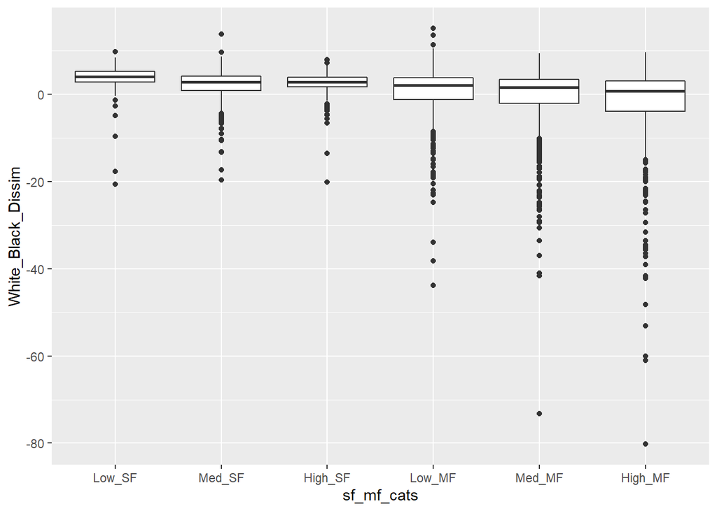

```r
du_cat_dissim<-ggplot(flu_dissim, aes(x=sf_mf_cats, y=White_Black_Dissim))+geom_boxplot()

du_cat_dissim
```

It looks like a few categories can be collapsed. Med_SF/High_SF,

```r
low_sf<-3
med_high_sf<-10
low_mf<-25
med_mf<-75


# Add a variable for defining single family as greater than 0, but less than some max DU per acre
flu_dissim<-flu_dissim %>% mutate(sf_mf_cats = case_when(
    max_max_du<=low_sf ~ "Low_SF (less than 3 Du per acre)",
    max_max_du<=med_high_sf ~ "Med_High_SF (3-10)",
    max_max_du<=low_mf ~  "Low_MF (10-25)",
    max_max_du<=med_mf ~ "Med_MF(25-75)",
    max_max_du>=med_mf ~ "High_MF(75+)"
  ))

flu_dissim$sf_mf_cats <-factor(flu_dissim$sf_mf_cats, levels=c("Low_SF (less than 3 Du per acre)",
                                                               "Med_High_SF (3-10)",
                                                                "Low_MF (10-25)",
                                                               "Med_MF(25-75)",
                                                               "High_MF(75+)"))

flu_dissim %>% group_by(sf_mf_cats) %>% summarise(mean_dissim_white_black=mean(White_Black_Dissim))
```

| sf_mf_cats | mean_dissim_white_black |
| --- | --- |
| Low_SF (less than 3 Du per acre) | 3.7441323 |
| Med_High_SF (3-10) | 2.1196454 |
| Low_MF (10-25) | 0.4271322 |
| Med_MF(25-75) | -0.5239081 |
| High_MF(75+) | -2.1653188 |

```r
du_cat_dissim<-ggplot(flu_dissim, aes(x=sf_mf_cats, y=White_Black_Dissim))+geom_boxplot()


du_cat_dissim_aian<-ggplot(flu_dissim, aes(x=sf_mf_cats, y=White_AIAN_Dissim))+geom_boxplot()
```

```r
acs_rent_inc = read.csv("C:/Users/SChildress/Documents/GitHub/data-science/dissimilarity/census_tract_vars.csv")


# housing_policy<-read.xlsx("C:/Users/SChildress/Documents/GitHub/data-science/HHSurvey/estimation_displace/housing_policy_city.xlsx")
#
# housing_policy[is.na(housing_policy)]<-0
# housing_policy[housing_policy=='x']<-1


#flu_dissim$GEOID10 <- as.character(flu_dissim$GEOID10)
#acs_rent_inc$GEOID <- as.character(acs_rent_inc$GEOID)
flu_dissim <- merge(flu_dissim,acs_rent_inc, by.x='GEOID10', by.y='GEOID', all.x=TRUE)
```

```r
flu_dissim_model<-glm(White_Black_Dissim ~ sf_mf_cats,
                 data=flu_dissim)
```

https://datascience.stackexchange.com/questions/893/how-to-get-correlation-between-two-categorical-variable-and-a-categorical-variab

Looking to the correlation between the categories and the dissimiliarity index with a statistical test.

```r
anova = aov(White_Black_Dissim ~sf_mf_cats, data=flu_dissim)
summary(anova)
```

```
##               Df Sum Sq Mean Sq F value Pr(>F)
## sf_mf_cats     4   8457  2114.3   42.81 <2e-16 ***
## Residuals   2635 130128    49.4
## ---
## Signif. codes:  0 '***' 0.001 '**' 0.01 '*' 0.05 '.' 0.1 ' ' 1
```

```r
mean_low
```

| is_sf_low | mean_white_minority_dissim_low |
| --- | --- |
| 0 | -0.3025814 |
| 1 | 2.4772157 |